# GLMM Analysis Report

## Methods

Model was fitted using **lme4::glmer**.

Family: **binomial**

Formula: **AVAL ~ ARMCD + AGE + SEX + RACE + COMORBIDX + PRIORADM + (1|SITEID)**

## Model Fitting Diagnostics

This section reports diagnostics captured automatically at fit time and should be reviewed before interpreting the results below. A singular fit, a non-convergence message, or fitting warnings do not necessarily invalidate a model, but they do mean its estimates (particularly variance components) should be interpreted with caution.

| Check | Result |
| --- | --- |
| Singular fit | NO |
| Convergence | OK |

### Warnings raised during model fitting

*No warnings were raised while fitting this model.*

## Results

### Model Summary

Full summary output of the fitted model, as printed by R.

```
## Generalized linear mixed model fit by maximum likelihood (Laplace Approximation) ['glmerMod']
##  Family: binomial  ( logit )
## Formula: AVAL ~ ARMCD + AGE + SEX + RACE + COMORBIDX + PRIORADM + (1 |      SITEID)
##    Data: df
## Control: glmerControl(optimizer = "bobyqa", optCtrl = list(maxfun = 2e+05))
##
##       AIC       BIC    logLik -2*log(L)  df.resid
##     767.2     811.5    -373.6     747.2       614
##
## Scaled residuals:
##     Min      1Q  Median      3Q     Max
## -2.3574 -0.6786 -0.4465  0.8439  2.9293
##
## Random effects:
##  Groups Name        Variance Std.Dev.
##  SITEID (Intercept) 0.5462   0.7391
## Number of obs: 624, groups:  SITEID, 24
##
## Fixed effects:
##                                Estimate Std. Error z value Pr(>|z|)
## (Intercept)                   -3.432127   0.646783  -5.306 1.12e-07 ***
## ARMCDSTDCARE                   0.296814   0.189711   1.565 0.117686
## AGE                            0.026103   0.008147   3.204 0.001356 **
## SEXM                           0.254178   0.185582   1.370 0.170804
## RACEBLACK OR AFRICAN AMERICAN  0.124822   0.349837   0.357 0.721242
## RACEOTHER                      0.440387   0.431603   1.020 0.307561
## RACEWHITE                      0.463583   0.303797   1.526 0.127018
## COMORBIDX                      0.285331   0.081086   3.519 0.000433 ***
## PRIORADM                       0.263164   0.128057   2.055 0.039873 *
## ---
## Signif. codes:  0 '***' 0.001 '**' 0.01 '*' 0.05 '.' 0.1 ' ' 1
##
## Correlation of Fixed Effects:
##             (Intr) ARMCDS AGE    SEXM   RACOAA RACEOT RACEWH COMORB
## ARMCDSTDCAR -0.186
## AGE         -0.818  0.036
## SEXM        -0.114  0.066 -0.071
## RACEBLACOAA -0.393  0.018  0.046  0.037
## RACEOTHER   -0.259 -0.037 -0.029  0.067  0.509
## RACEWHITE   -0.439 -0.039  0.036  0.059  0.735  0.600
## COMORBIDX    0.087 -0.097 -0.271 -0.042  0.001  0.015  0.033
## PRIORADM    -0.052 -0.015 -0.038  0.013  0.009 -0.027  0.014 -0.159
```

### Random Effects

Both the **variance** (σ²) and the **standard deviation** (σ) of each random-effect term are shown. The residual row is the within-group (observation-level) variance.

Random-effects variance components

| Group | Effect | Variance | Std.Dev. |
| --- | --- | --- | --- |
| SITEID | (Intercept) | 0.5462 | 0.7391 |

*For non-Gaussian GLMMs the random-effects variances are on the link (latent) scale, and there is no separate residual variance.*

### Fixed Effects

Estimate

Std. Error

z value

Pr(>|z|)

(Intercept)

-3.432

0.647

-5.306

< 1e-04

***

ARMCDSTDCARE

0.297

0.190

1.565

0.117686

AGE

0.026

0.008

3.204

0.001356

SEXM

0.254

0.186

1.370

0.170804

RACEBLACK OR AFRICAN AMERICAN

0.125

0.350

0.357

0.721242

RACEOTHER

0.440

0.432

1.020

0.307561

RACEWHITE

0.464

0.304

1.526

0.127018

COMORBIDX

0.285

0.081

3.519

0.000433

***

PRIORADM

0.263

0.128

2.055

0.039873

```
## Analysis of Variance Table
##           npar  Sum Sq Mean Sq F value
## ARMCD        1  3.8813  3.8813  3.8813
## AGE          1 23.3438 23.3438 23.3438
## SEX          1  2.0037  2.0037  2.0037
## RACE         3  3.0392  1.0131  1.0131
## COMORBIDX    1 15.5119 15.5119 15.5119
## PRIORADM     1  4.3099  4.3099  4.3099
```

### Model Performance

Variance explained and clustering (R2, ICC)

| Metric | Value |
| --- | --- |
| R2 marginal (fixed effects only) | 0.1140 |
| R2 conditional (fixed + random effects) | 0.2402 |
| ICC (adjusted) | 0.1424 |
| ICC (unadjusted) | 0.1262 |

Information criteria and error measures

| Metric | Value |
| --- | --- |
| AIC | 7.672e+02 |
| AICc | 7.675e+02 |
| BIC | 8.115e+02 |
| RMSE | 4.348e-01 |
| Sigma | 1.000e+00 |
| Log_loss | 5.595e-01 |
| Score_log | -1.334e+02 |
| Score_spherical | 1.603e-03 |

**How to read these measures**

- **R2 marginal**: proportion of variance explained by the fixed effects alone.
- **R2 conditional**: proportion of variance explained by the fixed and random effects together.
- **ICC**: proportion of the total (non-fixed-effect) variance attributable to differences between groups/subjects; higher values mean observations within the same group are more alike.
- For non-Gaussian GLMMs, R2 and ICC are computed on the latent (link) scale, so they are not directly comparable to Gaussian-model values.

### DHARMa Residual Diagnostics

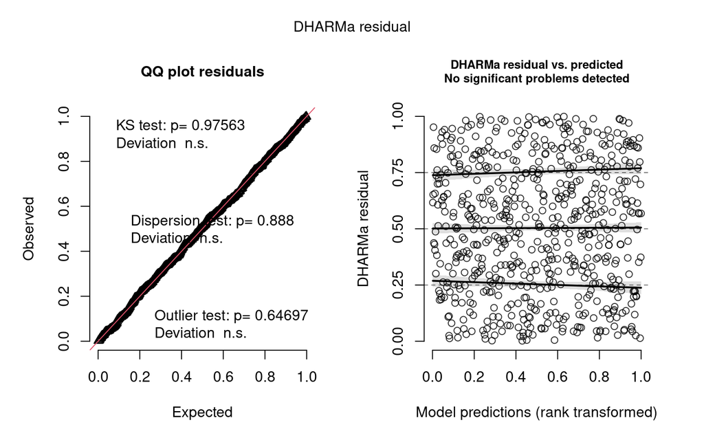